# STRI Champaign Project 2019

```
See the output for common issues in summer months below:
```

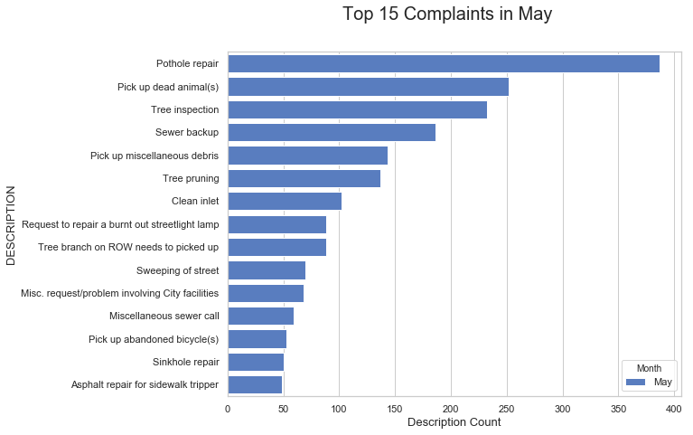

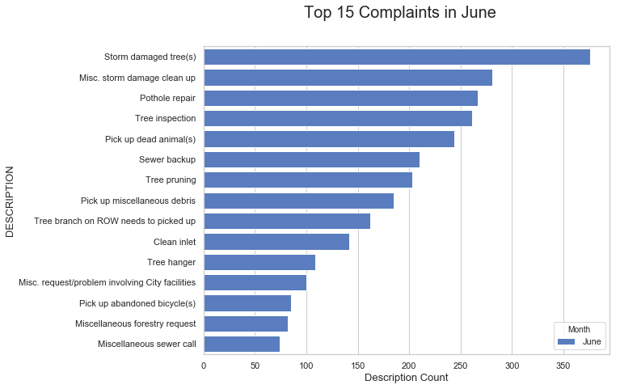

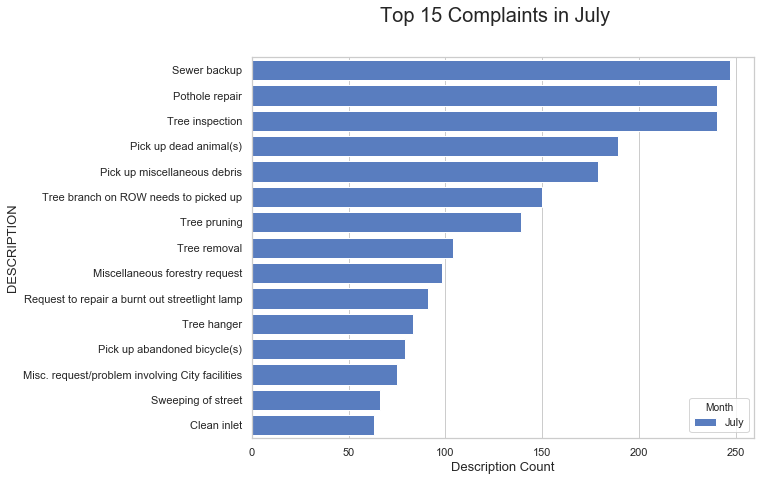

```python
# Here, the results for summer are shown
print("See the output for common issues in summer months below:")
print("")

month_function('May')
month_function('June')
month_function('July')
```

```
See the output for common issues in fall months below:
```

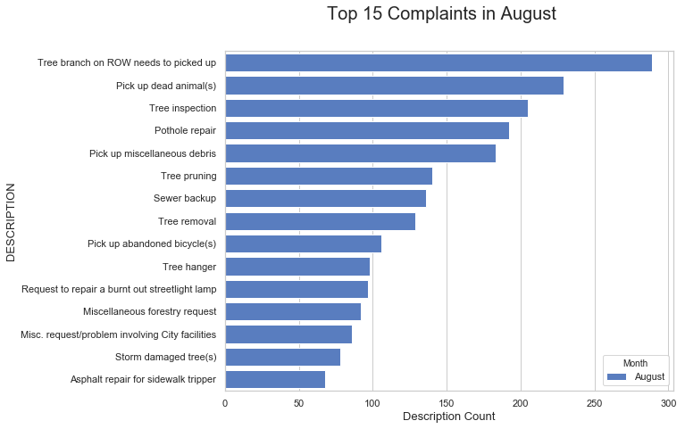

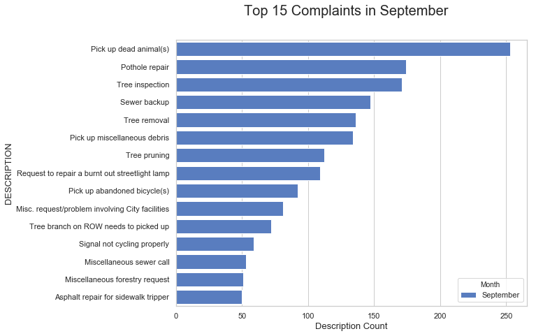

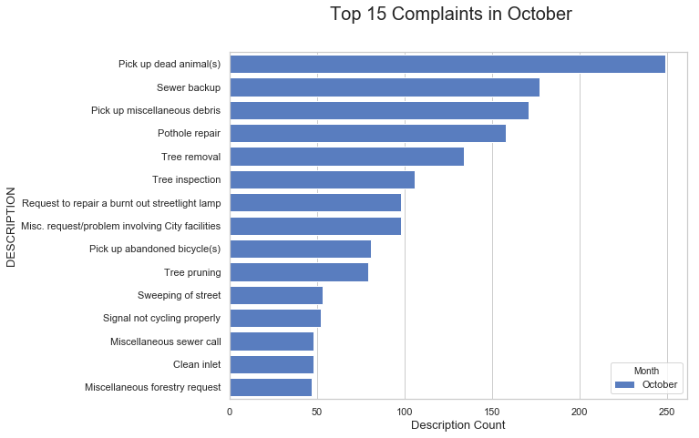

```python
# Here, the results fall are shown
print("See the output for common issues in fall months below:")
print("")

month_function('August')
month_function('September')
month_function('October')
```

[Back to TOC]

## Top Issues by Year

In this section, I group the data by year (e.g., 2010, 2011, 2012) and create barplots of the top issues by year. First, I provide an overall overview of the number of issues reported per year. This section has been updated with the most recent data from 2018.

*** YEAR UPDATED WITH 2018

```python
# Extract year information from datetime column
cityWorks['Year'] = cityWorks['DATETIMEINIT'].map(lambda x: x.year)
```

```python
# see our result from adding year to our dataframe
cityWorks.sample(3)
```

|  | # of SR | DESCRIPTION | DATETIMEINIT | DATETIMECLOSED | STATUS | PROBADDRESS | PROBLOCATION | SRX | SRY | month_int | Month | Year |
| --- | --- | --- | --- | --- | --- | --- | --- | --- | --- | --- | --- | --- |
| 1740 | 1770 | Clean inlet | 2010-06-16 08:24:20 | 2010-06-19 13:27:49 | CLOSED | W JOHN ST / S DUNCAN RD | NaN | 994854.00 | 1253748.00 | 6 | June | 2010 |
| 5216 | 5250 | Misc. request/problem involving City facilities | 2011-05-05 10:14:26 | 2011-05-25 14:55:27 | CLOSED | 102 N NEIL ST | NaN | 1009517.00 | 1256347.00 | 5 | May | 2011 |
| 30222 | 30378 | Tree inspection | 2017-07-25 13:53:07 | 2017-07-27 08:57:08 | CLOSED | 1404 Old Farm Rd | NaN | 1001830.66 | 1247846.32 | 7 | July | 2017 |

```
See figure below for breakdown of complaints by year:
```

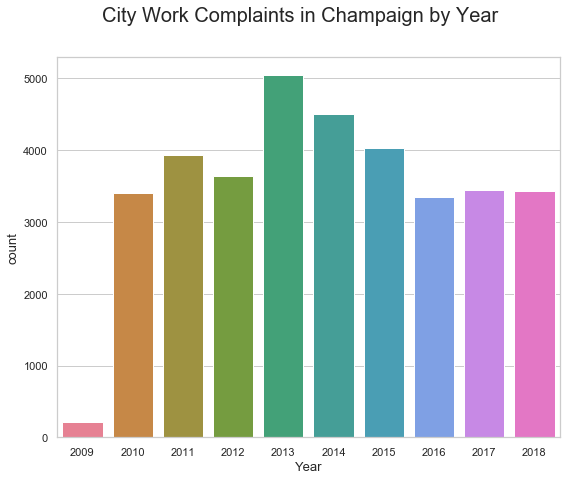

```python
# create a plot for number of complaints by year
print("See figure below for breakdown of complaints by year:")
print("")

# create plot
f, ax = plt.subplots(figsize=(9, 7))
sns.set(style="whitegrid")
ax.set_xlabel("Year", size=13)
ax.set_ylabel("Complaint Count", size=13)
suptitle("City Work Complaints in Champaign by Year", size=20)
ax = sns.countplot(x="Year", data=cityWorks, palette='husl')

fig = ax.get_figure()
```

```python
def year_function(year):

    year_x = cityWorks[cityWorks['Year']== year]
    year_x['Description Count'] = year_x.groupby('DESCRIPTION')['DESCRIPTION'].transform('count')
    sorted_year = year_x.sort_values('Description Count',  ascending=False)
    sort5_year = sorted_year.drop_duplicates(subset=['DESCRIPTION']).head(15)

    f, ax = plt.subplots(figsize=(9, 7))
    sns.set(style="whitegrid")
    ax.set_xlabel("Year", size=13)
    ax.set_ylabel("Complaint Count", size=13)
    suptitle("Top 15 Complaints {0}".format(year), size=20)
    ax = sns.barplot(x="Description Count",y='DESCRIPTION', data=sort5_year, palette='muted', hue='Year')

    fig = ax.get_figure()
```

```
See the top complaints from 2010 to 2012 below:
```

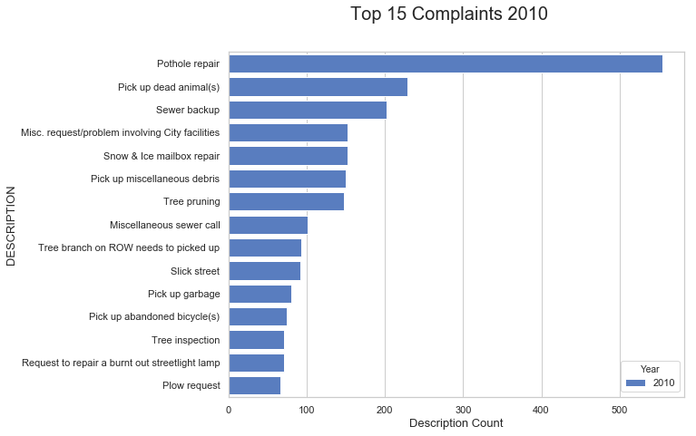

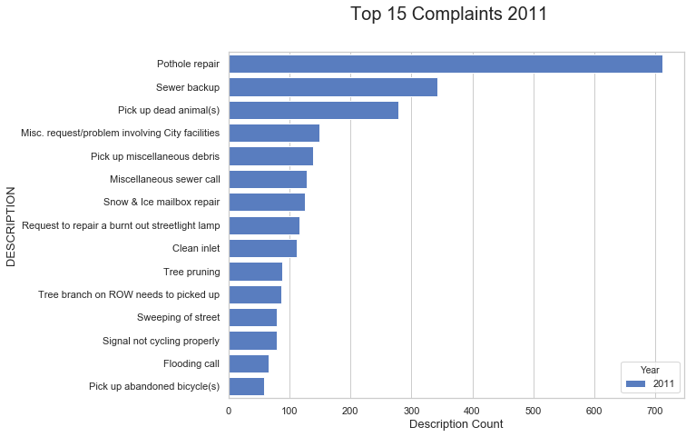

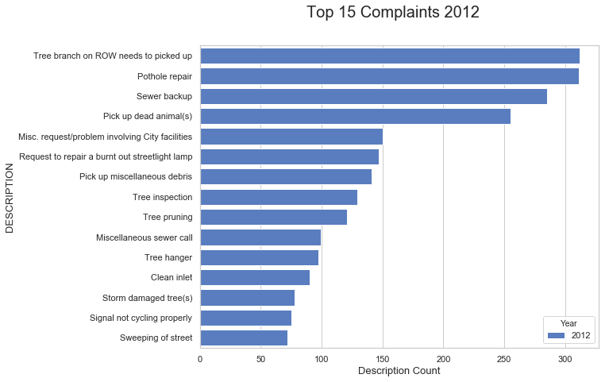

```python
print("See the top complaints from 2010 to 2012 below:")
year_function(2010)
year_function(2011)
year_function(2012)
```

```
See the top complaints from 2013 to 2015 below:
```

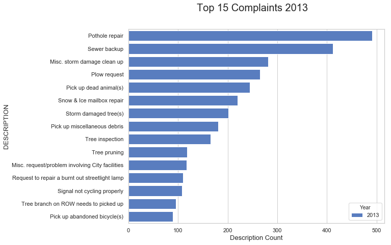

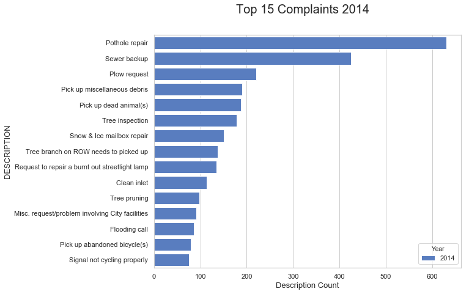

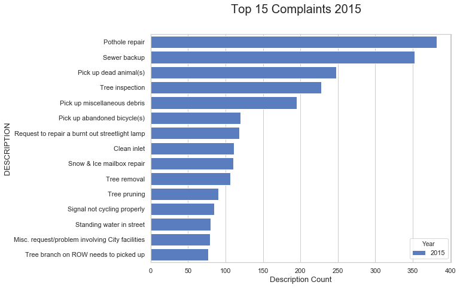

```python
print("See the top complaints from 2013 to 2015 below:")
year_function(2013)
year_function(2014)
year_function(2015)
```

[output not shown]

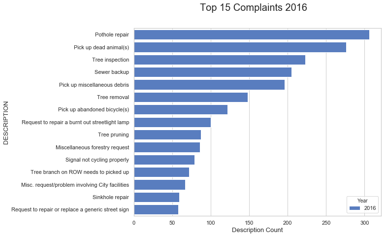

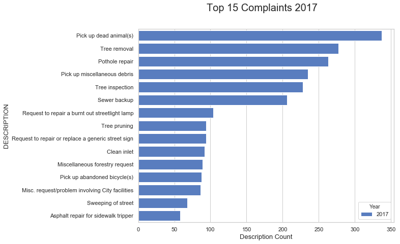

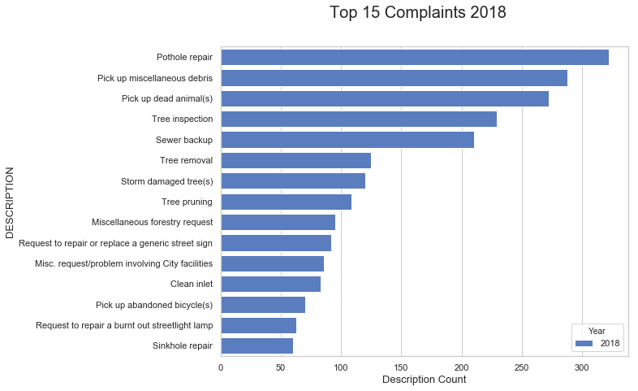

```python
print("See the top complaints from 2016 to 2017 below:")
year_function(2016)
year_function(2017)
year_function(2018)
```

[Back to TOC]

## Complaints by Addresses

```python
cityWorks2 = pd.read_excel("data_2.xls")
```

```python
# get most common complaint addresses
locations = cityWorks2.groupby('PROBADDRESS').filter(lambda x:len(x) > 150)
```

```
See the top addresses for complaints in Champaign below:
```

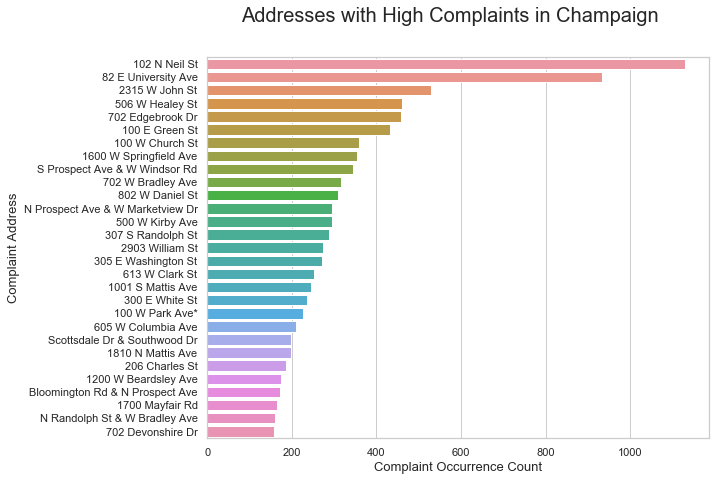

```python
print("See the top addresses for complaints in Champaign below:")
print("")
# graph the most common complaints addresses
f, ax = plt.subplots(figsize=(9, 7))
ax = sns.countplot(y="PROBADDRESS", data=locations,
                   order=locations['PROBADDRESS'].value_counts().index)
#ax.set_xticklabels(ax.get_xticklabels(),rotation=90)
ax.set_xlabel("Complaint Occurrence Count", size=13)
ax.set_ylabel("Complaint Address", size=13)
suptitle("Addresses with High Complaints in Champaign", size=20)
fig = ax.get_figure()

#fig.savefig("topcityworksplot",bbox_inches="tight")
```

```python
# get least common complaint addresses
locations_least = cityWorks2.groupby('PROBADDRESS').filter(lambda x:len(x) < 20)
```

```python
locations_least_new = locations_least.sample(10)
```

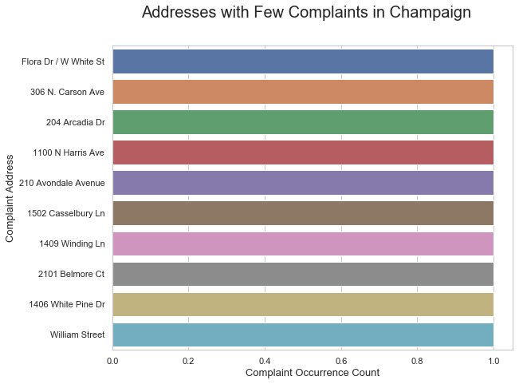

```python
# graph the least common complaints addresses
f, ax = plt.subplots(figsize=(9, 7))
ax = sns.countplot(y="PROBADDRESS", data=locations_least_new,
                   order=locations_least_new['PROBADDRESS'].value_counts().index)
#ax.set_xticklabels(ax.get_xticklabels(),rotation=90)
ax.set_xlabel("Complaint Occurrence Count", size=13)
ax.set_ylabel("Complaint Address", size=13)
suptitle("Addresses with Few Complaints in Champaign", size=20)
fig = ax.get_figure()

#fig.savefig("topcityworksplot",bbox_inches="tight")
```

[Back to TOC]

## Geographic Data

Here, I upload a cleaned dataframe (I cleaned it using OpenRefine) that would allow me to work with the geographic data. Still figuring out how to work with this component.

```python
# Now some mapping
# first, import the CSV that has the coordinates as int, no commas
cityWorks_int = pd.read_csv("Cleaned_cityworks.csv")
cityWorks_int.sample(2)
```

|  | # of SR | DESCRIPTION | DATETIMEINIT | DATETIMECLOSED | STATUS | PROBADDRESS | Longitude | Latitude |
| --- | --- | --- | --- | --- | --- | --- | --- | --- |
| 30948 | 31106 | Pick up dead animal(s) | Mon Oct 02 08:54:07 CDT 2017 | Tue Oct 03 15:52:20 CDT 2017 | CLOSED | Buena Vista Dr & Frederick St | 1008826.10 | 1250800.90 |
| 30163 | 30319 | Tree removal | Thu Jul 20 09:18:55 CDT 2017 | Thu Jul 20 13:07:00 CDT 2017 | CLOSED | 901 Park Lane Dr | 1005347.94 | 1243225.41 |

```python
# now that we input the numberical csv, let's map using reduced coordinates
cityWorks_int["Long"] = cityWorks_int.iloc[:,6]/100000
cityWorks_int["Lat"] = cityWorks_int.iloc[:,7]/100000

cityWorks_int.sample(2)
```

|  | # of SR | DESCRIPTION | DATETIMEINIT | DATETIMECLOSED | STATUS | PROBADDRESS | Longitude | Latitude | Long | Lat |
| --- | --- | --- | --- | --- | --- | --- | --- | --- | --- | --- |
| 24496 | 24634 | Report of a traffic signal that has been damaged | Fri Dec 04 09:33:32 CST 2015 | Mon Dec 14 12:13:39 CST 2015 | CLOSED | W University Ave & S Country Fair Dr | 998691.51 | 1256350.20 | 9.986915 | 12.563502 |
| 18854 | 18987 | Tree branch on ROW needs to picked up | Tue Jul 01 14:11:33 CDT 2014 | Thu Jul 31 11:46:13 CDT 2014 | CLOSED | 1216 W Healey St | 1002884.30 | 1254711.75 | 10.028843 | 12.547118 |

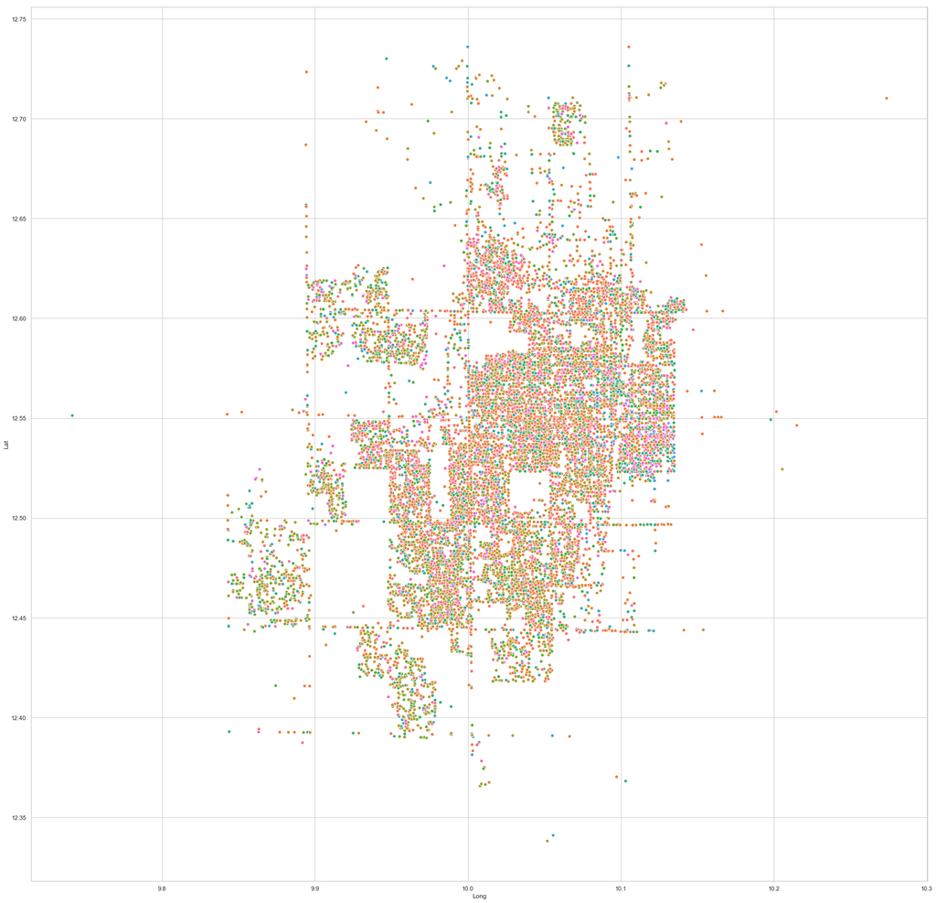

```python
# This is way too big, I'm going to reduce it to only the top occuring complaints
f, ax = plt.subplots(figsize=(30,30))
ax = sns.scatterplot(x='Long', y='Lat', hue='DESCRIPTION', data=cityWorks_int, legend=False)

fig = ax.get_figure()

#fig.savefig("mappedoutcitywork",bbox_inches="tight")
```

```python
# Define a new row for top occuring issues
def top_issues (row):
    if row['DESCRIPTION'] == 'Pothole repair' :
        return 1
    if row['DESCRIPTION'] == 'Sewer backup' :
        return 1
    if row['DESCRIPTION'] == 'Pick up dead animal(s)' :
        return 1
    if row['DESCRIPTION'] == 'Pick up miscellaneous debris' :
        return 1
    if row['DESCRIPTION'] == 'Tree inspection' :
        return 1
    if row['DESCRIPTION'] == 'Tree branch on ROW needs to picked up' :
        return 1
    if row['DESCRIPTION'] == 'Request to repair a burnt out streetlight lamp' :
        return 1
    if row['DESCRIPTION'] == 'Misc. request/problem involving City facilities' :
        return 1
    if row['DESCRIPTION'] == 'Tree pruning' :
        return 1
    if row['DESCRIPTION'] == 'Snow & Ice mailbox repair' :
        return 1
    if row['DESCRIPTION'] == 'Clean inlet' :
        return 1
    if row['DESCRIPTION'] == 'Tree removal' :
        return 1
    if row['DESCRIPTION'] == 'Signal not cycling properly' :
        return 1
    if row['DESCRIPTION'] == 'Plow request' :
        return 1
    else:
        return np.nan
```

```python
# create new column with the above data, create new dataframe and remove all nan
cityWorks_int['top_issues'] = cityWorks_int.apply(lambda row: top_issues(row),axis=1)
```

```python
# drop all instances where there is an nan
cityWorks_intMap = cityWorks_int.dropna()
```

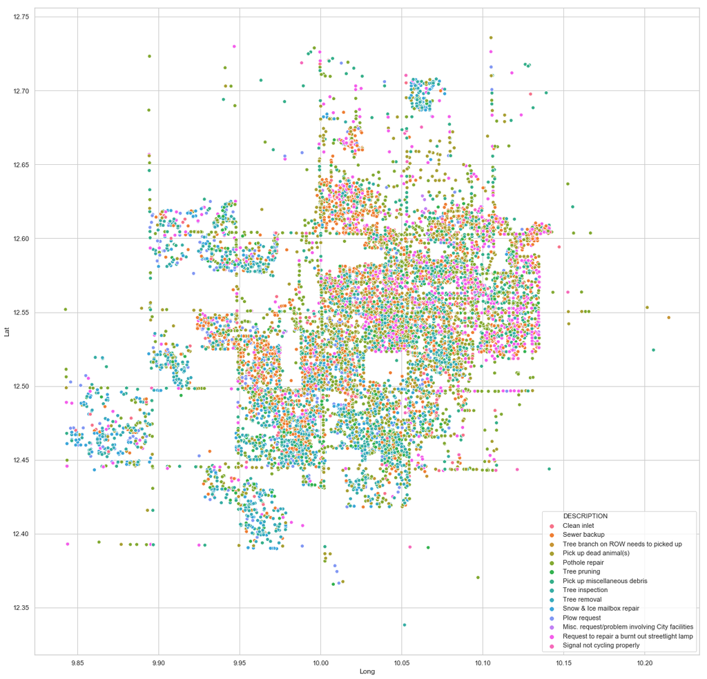

```python
# now that's better, took only the top occuring instances to map
f, ax = plt.subplots(figsize=(20,20))
ax = sns.scatterplot(x='Long', y='Lat', hue='DESCRIPTION', data=cityWorks_intMap, legend='full')

fig = ax.get_figure()

fig.savefig("mappedoutcitywork",bbox_inches="tight")
```

[Back to TOC]

## Data Visualizations from Tableau

The following code cells show some data visuals from Tableau and other external visualization sources.

```python
print("Below is an image of the coordiantes as visualized on Champaign Map")

print(" ")
```

```
Below is an image of the coordiantes as visualized on Champaign Map
```

[figure not shown]

```python
print("Below are Images of Open/Closed Issues and a Heatmap of Complaints")

print(" ")
```

```
Below are Images of Open/Closed Issues and a Heatmap of Complaints
```

[figure not shown]

```python
print("Below see Output for Issues by Address in Champaign")

print(" ")
```

```
Below see Output for Issues by Address in Champaign
```

[figure not shown]

[Back to TOC]

## Contact STRI

- Joe Yun | Lab Leader [jtyun@illinois.edu]
- Julian Chin | Research Manager [cchin6@illinois.edu]
- Kat Tian | Researcher [kathyt2@illinois.edu]
- Website | [https://srtilab.techservices.illinois.edu/about/]

© Social Research and Technology Innovation Laboratory